# QuynhNga_test

EDA AND XGBOOST FOR EQUIPMENT FAILURE PREDICTION

Hanoi, 16/09/2024

Brief explanations for analysis and models for the demo of Equipment Failure Prediction.

Part 1: Exploratory Data Analysis (EDA)

For possessing overall understanding of data, we will see basic information on full data, and following EDA will be carried out on training set cause deep dive EDA for the purpose of predicting should be carried out on training set. We do more EDA (above the request) to see the insight. I have divided set into train and test set from such phase.

Details I have included in code and concise comment

Part 2: XGBoost Model

From EDA, we do feature engineer. I build a pipeline for training data. It is found that: precision, recall, f1-score (for label_1) is 0, because in training set, we only have 15 records of label_1 (and in test set we also have only 4 records of label_1). So,model may not learn the pattern to exact predict 4 records of label_1 in test set. Cause we have only 190 records for all training and testing.

I have tried scale_pos_weight between negative and positive class to allow the model to compensate for imbalanced data. Scale_pos_weight is assigning more weight to the minority class, making the model more sensitive to misclassifications of the minority class. Also, I tried hyperparameter tuning by randomized search approach for: nestimators ,max_depth ,learning_rate , subsample, colsample_bytree, gamma ,min_child_weight, however, it still does not work well for better predictions.

In reality, wish we can have more data (both positive and negative labels) to learn and test more. I’m so sorry but cause we don’t have many data to train and to put more data involved in imbalance dataset, if we have more data available I will put more positive data into training to enhance the predicting powers.

Hope you can sympathize for that <3.

# `EDA and XGBoost for Equipment Failure Prediction`

```python
import pandas as pd
import numpy as np
from IPython.core.interactiveshell import InteractiveShell
InteractiveShell.ast_node_interactivity = "all"
import plotly.express as px
import seaborn as sns
%matplotlib inline
import matplotlib.pyplot as plt
pd.set_option('display.max_columns', None)

from sklearn.model_selection import train_test_split
from xgboost import XGBClassifier
from sklearn.compose import make_column_selector as selector
from sklearn.pipeline import Pipeline
from sklearn.preprocessing import StandardScaler, OneHotEncoder
from sklearn.impute import SimpleImputer
from sklearn.compose import ColumnTransformer
from sklearn.metrics import accuracy_score
from sklearn.metrics import classification_report, precision_score, recall_score, f1_score
from sklearn.model_selection import RandomizedSearchCV
import copy
from sklearn.metrics import roc_curve, roc_auc_score
```

# Part 1: Exploratory Data Analysis (EDA)

1. Load the dataset and display basic information (rows, columns, data types).
2. Show the distribution of the target variable (failure_last).
3. Create a correlation heatmap for numerical features.
4. Identify the top 3 features most correlated with failure_last.

## 1.1 Load the dataset and display basic information (rows, columns, data types).

```python
read_file = pd.read_csv('batch_and_sensor_next.csv')
read_file
```

|  | equipment_id | recipe_first | recipe_last | batch_id_last | start_time_last | end_time_first | failure_first | failure_last | sensor_0_sensor_value_avg_min_first | sensor_0_sensor_value_avg_max_first | sensor_0_sensor_value_avg_count_first | sensor_0_sensor_value_avg_avg_first | sensor_0_sensor_value_avg_stddev_first | sensor_1_sensor_value_avg_min_first | sensor_1_sensor_value_avg_max_first | sensor_1_sensor_value_avg_count_first | sensor_1_sensor_value_avg_avg_first | sensor_1_sensor_value_avg_stddev_first | sensor_2_sensor_value_avg_min_first | sensor_2_sensor_value_avg_max_first | sensor_2_sensor_value_avg_count_first | sensor_2_sensor_value_avg_avg_first | sensor_2_sensor_value_avg_stddev_first | sensor_3_sensor_value_avg_min_first | sensor_3_sensor_value_avg_max_first | sensor_3_sensor_value_avg_count_first | sensor_3_sensor_value_avg_avg_first | sensor_3_sensor_value_avg_stddev_first | sensor_4_sensor_value_avg_min_first | … |
| --- | --- | --- | --- | --- | --- | --- | --- | --- | --- | --- | --- | --- | --- | --- | --- | --- | --- | --- | --- | --- | --- | --- | --- | --- | --- | --- | --- | --- | --- | --- |
| 0 | equipment_0 | program_1 | program_38 | batch_158 | 2018-02-04T01:23:18.000Z | 2018-02-02T02:50:59.000Z | 0 | 0 | 0.811629 | 1.515141 | 7 | 1.226897 | 0.358544 | 0.0 | 0.215118 | 8985 | 0.010069 | 0.030313 | 0.015266 | 0.03701 | 4 | 0.021452 | 0.010437 | 23.89059 | 50.95204 | 8 | 33.738225 | 12.884381 | NaN | … |
| 1 | equipment_0 | program_38 | program_12 | batch_97 | 2018-02-04T06:34:23.000Z | 2018-02-04T04:37:28.000Z | 0 | 0 | 0.254922 | 10.000000 | 68 | 1.655387 | 2.038396 | 0.0 | 4.537109 | 6131 | 0.142189 | 0.745196 | 0.000000 | 40.08755 | 131 | 18.524266 | 14.471954 | 41.17049 | 80.32930 | 89 | 70.058525 | 6.719890 | 0.0 | … |
| 2 | equipment_0 | program_12 | program_29 | batch_310 | 2018-02-06T00:37:13.000Z | 2018-02-04T10:57:59.000Z | 0 | 0 | 0.844739 | 0.889188 | 4 | 0.868543 | 0.019534 | 0.0 | 0.206421 | 6359 | 0.007962 | 0.025976 | NaN | NaN | 0 | NaN | NaN | 28.84071 | 33.76286 | 5 | 31.063304 | 1.967552 | NaN | … |
| 3 | equipment_0 | program_29 | program_12 | batch_98 | 2018-02-06T18:54:19.000Z | 2018-02-06T03:10:03.000Z | 0 | 0 | 0.304645 | 10.000000 | 103 | 2.117966 | 2.301684 | 0.0 | 32.951130 | 4730 | 6.698391 | 7.214862 | 0.000000 | 64.52193 | 499 | 30.011059 | 22.913938 | 31.61253 | 79.42979 | 205 | 66.093545 | 10.701315 | 0.0 | … |
| 4 | equipment_0 | program_12 | program_38 | batch_153 | 2018-02-06T22:00:22.000Z | 2018-02-06T22:19:02.000Z | 0 | 0 | 0.177200 | 10.000000 | 113 | 2.069068 | 2.526102 | 0.0 | 33.109770 | 5938 | 5.291316 | 6.448885 | 0.000000 | 56.82596 | 592 | 18.821964 | 15.003655 | 28.98676 | 79.42699 | 248 | 66.697469 | 10.457978 | 0.0 | … |
| ... | ... | ... | ... | ... | ... | ... | ... | ... | ... | ... | ... | ... | ... | ... | ... | ... | ... | ... | ... | ... | ... | ... | ... | ... | ... | ... | ... | ... | ... | … |
| 185 | equipment_1 | program_52 | program_11 | batch_135 | 2018-03-26T22:28:27.000Z | 2018-03-26T05:02:04.000Z | 0 | 0 | 0.134959 | 10.000000 | 101 | 3.682707 | 3.283279 | 0.0 | 40.762410 | 3211 | 8.051550 | 7.376761 | 0.000000 | 49.37247 | 551 | 21.381908 | 13.822646 | 26.20461 | 83.63255 | 553 | 65.749663 | 10.557716 | 0.0 | … |
| 186 | equipment_1 | program_11 | program_31 | batch_147 | 2018-03-28T20:14:21.000Z | 2018-03-27T00:08:44.000Z | 0 | 0 | 0.168353 | 10.000000 | 69 | 2.086345 | 2.801094 | 0.0 | 35.853030 | 3460 | 6.957391 | 7.221726 | 0.000000 | 44.70218 | 375 | 21.292707 | 14.251543 | 28.33350 | 77.71568 | 171 | 63.720833 | 11.540735 | 0.0 | … |
| 187 | equipment_1 | program_31 | program_45 | batch_186 | 2018-03-28T22:25:05.000Z | 2018-03-28T22:00:54.000Z | 0 | 0 | 0.197688 | 10.000000 | 102 | 2.032279 | 2.390404 | 0.0 | 34.010040 | 2782 | 8.162075 | 7.097335 | 0.000000 | 49.90704 | 349 | 16.175986 | 14.075947 | 26.09184 | 78.70038 | 187 | 64.262538 | 10.937187 | 0.0 | … |
| 188 | equipment_1 | program_45 | program_20 | batch_64 | 2018-03-29T15:25:55.000Z | 2018-03-29T01:05:54.000Z | 0 | 0 | 0.133426 | 10.000000 | 167 | 3.018383 | 2.855964 | 0.0 | 38.262270 | 3270 | 9.168866 | 7.430458 | 0.000000 | 59.58300 | 596 | 23.880034 | 16.857795 | 25.87759 | 79.98228 | 292 | 65.374186 | 10.384542 | 0.0 | … |
| 189 | equipment_1 | program_20 | program_22 | batch_111 | 2018-03-29T17:35:43.000Z | 2018-03-29T17:35:46.000Z | 0 | 1 | 0.140233 | 10.000000 | 207 | 4.671507 | 3.671755 | 0.0 | 32.478180 | 2925 | 8.286326 | 7.326857 | 0.000000 | 63.88218 | 564 | 27.241401 | 19.632228 | 29.90956 | 79.38623 | 281 | 65.322278 | 10.489881 | 0.0 | … |

190 rows × 55 columns

```python
read_file.shape
read_file.describe()
```

```
(190, 55)
```

|  | failure_first | failure_last | sensor_0_sensor_value_avg_min_first | sensor_0_sensor_value_avg_max_first | sensor_0_sensor_value_avg_count_first | sensor_0_sensor_value_avg_avg_first | sensor_0_sensor_value_avg_stddev_first | sensor_1_sensor_value_avg_min_first | sensor_1_sensor_value_avg_max_first | sensor_1_sensor_value_avg_count_first | sensor_1_sensor_value_avg_avg_first | sensor_1_sensor_value_avg_stddev_first | sensor_2_sensor_value_avg_min_first | sensor_2_sensor_value_avg_max_first | sensor_2_sensor_value_avg_count_first | sensor_2_sensor_value_avg_avg_first | sensor_2_sensor_value_avg_stddev_first | sensor_3_sensor_value_avg_min_first | sensor_3_sensor_value_avg_max_first | sensor_3_sensor_value_avg_count_first | sensor_3_sensor_value_avg_avg_first | sensor_3_sensor_value_avg_stddev_first | sensor_4_sensor_value_avg_min_first | sensor_4_sensor_value_avg_max_first | sensor_4_sensor_value_avg_count_first | sensor_4_sensor_value_avg_avg_first | sensor_4_sensor_value_avg_stddev_first | sensor_5_sensor_value_avg_min_first | sensor_5_sensor_value_avg_max_first | … |
| --- | --- | --- | --- | --- | --- | --- | --- | --- | --- | --- | --- | --- | --- | --- | --- | --- | --- | --- | --- | --- | --- | --- | --- | --- | --- | --- | --- | --- | --- | --- |
| count | 190.000000 | 190.000000 | 185.000000 | 185.000000 | 190.000000 | 185.000000 | 183.000000 | 190.0 | 190.000000 | 190.000000 | 190.000000 | 190.000000 | 180.000000 | 180.000000 | 190.000000 | 180.000000 | 177.000000 | 189.000000 | 189.000000 | 190.000000 | 189.000000 | 184.000000 | 164.000000 | 164.000000 | 190.000000 | 164.000000 | 163.000000 | 190.000000 | 190.000000 | … |
| mean | 0.094737 | 0.100000 | 0.416664 | 8.541271 | 120.089474 | 2.570657 | 2.273112 | 0.0 | 27.918226 | 5108.352632 | 5.626948 | 5.398314 | 0.142343 | 56.505919 | 431.963158 | 20.858857 | 16.537717 | 28.088333 | 73.124137 | 222.273684 | 58.314605 | 10.312906 | 0.719708 | 83.538281 | 516.410526 | 56.194127 | 19.933224 | 0.547362 | 86.221826 | … |
| std | 0.293625 | 0.300793 | 0.818828 | 3.318075 | 103.113475 | 1.430313 | 1.044342 | 0.0 | 16.579144 | 6126.111386 | 3.710326 | 3.062182 | 1.889722 | 23.028879 | 372.523787 | 8.323637 | 6.272170 | 5.306665 | 17.130854 | 192.513172 | 12.577043 | 3.826646 | 5.427958 | 9.599492 | 476.016339 | 6.986445 | 3.483873 | 5.618290 | 33.976324 | … |
| min | 0.000000 | 0.000000 | 0.000000 | 0.000000 | 0.000000 | 0.000000 | 0.000000 | 0.0 | 0.027184 | 11.000000 | 0.004394 | 0.008060 | 0.000000 | 0.009819 | 0.000000 | 0.001637 | 0.004009 | 17.599550 | 21.058460 | 0.000000 | 21.020907 | 0.013233 | 0.000000 | 45.050590 | 0.000000 | 35.865200 | 7.063694 | 0.000000 | 0.051910 | … |
| 25% | 0.000000 | 0.000000 | 0.158208 | 10.000000 | 58.000000 | 1.678802 | 2.119363 | 0.0 | 17.641977 | 2838.000000 | 1.215771 | 2.506868 | 0.000000 | 49.830687 | 251.000000 | 17.539277 | 14.389663 | 25.619890 | 77.780400 | 120.250000 | 59.877372 | 10.421442 | 0.000000 | 78.613703 | 228.250000 | 52.095458 | 17.973040 | 0.000000 | 100.000000 | … |
| 50% | 0.000000 | 0.000000 | 0.191888 | 10.000000 | 102.000000 | 2.290579 | 2.563835 | 0.0 | 33.311293 | 3416.500000 | 7.268686 | 7.097263 | 0.000000 | 58.803785 | 388.000000 | 22.060037 | 16.534869 | 26.907300 | 79.428210 | 202.500000 | 63.887297 | 11.112091 | 0.000000 | 86.097340 | 449.000000 | 55.996220 | 20.373706 | 0.000000 | 100.000000 | … |
| 75% | 0.000000 | 0.000000 | 0.327165 | 10.000000 | 165.000000 | 3.247396 | 2.985593 | 0.0 | 36.407542 | 6040.000000 | 8.508118 | 7.344449 | 0.000000 | 67.963723 | 551.000000 | 26.845394 | 21.190307 | 28.380980 | 80.534470 | 285.750000 | 65.389430 | 11.988591 | 0.000000 | 89.233290 | 700.250000 | 62.326725 | 22.547090 | 0.000000 | 100.000000 | … |
| max | 1.000000 | 1.000000 | 6.879106 | 10.000000 | 727.000000 | 8.281791 | 3.735256 | 0.0 | 63.683590 | 61741.000000 | 14.278968 | 8.726667 | 25.354480 | 102.434400 | 3232.000000 | 38.831013 | 29.172439 | 54.513700 | 100.000000 | 1811.000000 | 70.632551 | 22.127854 | 50.995170 | 100.000000 | 3284.000000 | 70.888737 | 26.144541 | 69.549740 | 100.000000 | … |

```python
read_file.info()
```

```
<class 'pandas.core.frame.DataFrame'>
RangeIndex: 190 entries, 0 to 189
Data columns (total 55 columns):
 #   Column                                  Non-Null Count  Dtype
---  ------                                  --------------  -----
 0   equipment_id                            190 non-null    object
 1   recipe_first                            190 non-null    object
 2   recipe_last                             190 non-null    object
 3   batch_id_last                           190 non-null    object
 4   start_time_last                         190 non-null    object
 5   end_time_first                          190 non-null    object
 6   failure_first                           190 non-null    int64
 7   failure_last                            190 non-null    int64
 8   sensor_0_sensor_value_avg_min_first     185 non-null    float64
 9   sensor_0_sensor_value_avg_max_first     185 non-null    float64
```

[output cut: 47 more lines]

## More eda

we only did EDA on train data cause if eda on all data(both train and test) it can be biased.

### EDA on both categorical and number columns

```python
#Split train and test
train_set, test_set = train_test_split(read_file, test_size=0.2, random_state=42)
train_set
```

|  | equipment_id | recipe_first | recipe_last | batch_id_last | start_time_last | end_time_first | failure_first | failure_last | sensor_0_sensor_value_avg_min_first | sensor_0_sensor_value_avg_max_first | sensor_0_sensor_value_avg_count_first | sensor_0_sensor_value_avg_avg_first | sensor_0_sensor_value_avg_stddev_first | sensor_1_sensor_value_avg_min_first | sensor_1_sensor_value_avg_max_first | sensor_1_sensor_value_avg_count_first | sensor_1_sensor_value_avg_avg_first | sensor_1_sensor_value_avg_stddev_first | sensor_2_sensor_value_avg_min_first | sensor_2_sensor_value_avg_max_first | sensor_2_sensor_value_avg_count_first | sensor_2_sensor_value_avg_avg_first | sensor_2_sensor_value_avg_stddev_first | sensor_3_sensor_value_avg_min_first | sensor_3_sensor_value_avg_max_first | sensor_3_sensor_value_avg_count_first | sensor_3_sensor_value_avg_avg_first | sensor_3_sensor_value_avg_stddev_first | sensor_4_sensor_value_avg_min_first | … |
| --- | --- | --- | --- | --- | --- | --- | --- | --- | --- | --- | --- | --- | --- | --- | --- | --- | --- | --- | --- | --- | --- | --- | --- | --- | --- | --- | --- | --- | --- | --- |
| 51 | equipment_0 | program_21 | program_21 | batch_104 | 2018-03-08T02:41:04.000Z | 2018-03-08T02:40:52.000Z | 1 | 0 | 0.464987 | 10.000000 | 23 | 1.950160 | 2.480706 | 0.0 | 0.207733 | 550 | 0.011249 | 0.032879 | 0.0 | 60.32517 | 86 | 18.181968 | 16.347176 | 27.20375 | 81.59172 | 32 | 60.426950 | 18.592655 | 0.0 | … |
| 35 | equipment_0 | program_12 | program_19 | batch_168 | 2018-03-03T16:49:16.000Z | 2018-03-03T16:48:32.000Z | 0 | 0 | 0.430736 | 10.000000 | 68 | 2.452373 | 2.493487 | 0.0 | 32.305100 | 6063 | 4.622575 | 6.612242 | 0.0 | 55.74435 | 425 | 16.529621 | 14.307934 | 28.99986 | 79.36687 | 252 | 66.263941 | 9.867670 | 0.0 | … |
| 118 | equipment_1 | program_13 | program_45 | batch_320 | 2018-03-04T02:26:47.000Z | 2018-03-03T23:54:16.000Z | 0 | 0 | 0.164084 | 10.000000 | 138 | 3.298390 | 3.174725 | 0.0 | 36.992130 | 2849 | 8.641409 | 7.201227 | 0.0 | 46.43481 | 653 | 17.127900 | 9.393321 | 25.17519 | 80.28879 | 286 | 65.799868 | 10.680016 | 0.0 | … |
| 60 | equipment_0 | program_35 | program_0 | batch_3 | 2018-03-10T04:43:24.000Z | 2018-03-10T11:50:54.000Z | 0 | 0 | 0.208578 | 10.000000 | 515 | 2.267079 | 2.463700 | 0.0 | 34.696115 | 34550 | 4.326624 | 6.550581 | 0.0 | 63.81887 | 2083 | 20.725898 | 17.431102 | 26.52454 | 80.07471 | 916 | 64.401235 | 11.813286 | 0.0 | … |
| 161 | equipment_1 | program_16 | program_24 | batch_215 | 2018-03-19T15:17:25.000Z | 2018-03-19T15:00:04.000Z | 0 | 0 | 0.177249 | 10.000000 | 70 | 1.907294 | 2.678397 | 0.0 | 32.920760 | 2837 | 8.890312 | 7.102976 | 0.0 | 49.36576 | 382 | 20.193163 | 14.249996 | 27.84932 | 78.78233 | 185 | 64.687893 | 11.161308 | 0.0 | … |
| ... | ... | ... | ... | ... | ... | ... | ... | ... | ... | ... | ... | ... | ... | ... | ... | ... | ... | ... | ... | ... | ... | ... | ... | ... | ... | ... | ... | ... | ... | … |
| 106 | equipment_1 | program_20 | program_31 | batch_159 | 2018-02-26T04:57:42.000Z | 2018-02-26T04:02:03.000Z | 0 | 0 | 0.123923 | 10.000000 | 147 | 3.770828 | 3.328738 | 0.0 | 33.041465 | 3013 | 7.868147 | 7.434057 | 0.0 | 63.94322 | 543 | 27.793766 | 19.667269 | 28.61917 | 79.81877 | 231 | 65.176866 | 11.405049 | 0.0 | … |
| 14 | equipment_0 | program_4 | program_21 | batch_28 | 2018-02-10T04:09:19.000Z | 2018-02-10T03:16:15.000Z | 0 | 0 | 0.327165 | 10.000000 | 64 | 2.290579 | 2.526153 | 0.0 | 35.349900 | 4876 | 4.591409 | 6.390334 | 0.0 | 42.67928 | 309 | 20.338750 | 15.350376 | 51.74153 | 80.80057 | 134 | 68.984856 | 6.129931 | 0.0 | … |
| 92 | equipment_1 | program_47 | program_45 | batch_260 | 2018-02-23T10:35:22.000Z | 2018-02-22T23:36:39.000Z | 0 | 0 | 0.205008 | 1.277466 | 35 | 0.556805 | 0.226764 | 0.0 | 0.060898 | 252 | 0.008561 | 0.012529 | 0.0 | 78.31723 | 285 | 25.065965 | 21.230746 | 24.92986 | 67.25381 | 188 | 45.995874 | 10.507050 | 0.0 | … |
| 179 | equipment_1 | program_48 | program_2 | batch_249 | 2018-03-25T02:01:26.000Z | 2018-03-25T01:22:04.000Z | 0 | 0 | 0.130591 | 10.000000 | 155 | 3.510802 | 3.072417 | 0.0 | 32.422530 | 3661 | 7.784976 | 7.461771 | 0.0 | 61.74669 | 533 | 27.552732 | 19.421783 | 25.57352 | 79.85538 | 270 | 65.731523 | 10.504027 | 0.0 | … |
| 102 | equipment_1 | program_36 | program_37 | batch_127 | 2018-02-25T11:42:49.000Z | 2018-02-25T11:54:49.000Z | 0 | 0 | 0.164500 | 10.000000 | 119 | 2.592905 | 2.979540 | 0.0 | 37.097200 | 3270 | 8.811681 | 7.197801 | 0.0 | 68.41550 | 443 | 27.233204 | 21.785028 | 28.23038 | 81.04427 | 241 | 64.495575 | 10.869978 | 0.0 | … |

152 rows × 55 columns

```python
# create copy for comfortable manipulating on data
eda_set = copy.deepcopy(train_set)
eda_set
eda_set.shape
```

|  | equipment_id | recipe_first | recipe_last | batch_id_last | start_time_last | end_time_first | failure_first | failure_last | sensor_0_sensor_value_avg_min_first | sensor_0_sensor_value_avg_max_first | sensor_0_sensor_value_avg_count_first | sensor_0_sensor_value_avg_avg_first | sensor_0_sensor_value_avg_stddev_first | sensor_1_sensor_value_avg_min_first | sensor_1_sensor_value_avg_max_first | sensor_1_sensor_value_avg_count_first | sensor_1_sensor_value_avg_avg_first | sensor_1_sensor_value_avg_stddev_first | sensor_2_sensor_value_avg_min_first | sensor_2_sensor_value_avg_max_first | sensor_2_sensor_value_avg_count_first | sensor_2_sensor_value_avg_avg_first | sensor_2_sensor_value_avg_stddev_first | sensor_3_sensor_value_avg_min_first | sensor_3_sensor_value_avg_max_first | sensor_3_sensor_value_avg_count_first | sensor_3_sensor_value_avg_avg_first | sensor_3_sensor_value_avg_stddev_first | sensor_4_sensor_value_avg_min_first | … |
| --- | --- | --- | --- | --- | --- | --- | --- | --- | --- | --- | --- | --- | --- | --- | --- | --- | --- | --- | --- | --- | --- | --- | --- | --- | --- | --- | --- | --- | --- | --- |
| 51 | equipment_0 | program_21 | program_21 | batch_104 | 2018-03-08T02:41:04.000Z | 2018-03-08T02:40:52.000Z | 1 | 0 | 0.464987 | 10.000000 | 23 | 1.950160 | 2.480706 | 0.0 | 0.207733 | 550 | 0.011249 | 0.032879 | 0.0 | 60.32517 | 86 | 18.181968 | 16.347176 | 27.20375 | 81.59172 | 32 | 60.426950 | 18.592655 | 0.0 | … |
| 35 | equipment_0 | program_12 | program_19 | batch_168 | 2018-03-03T16:49:16.000Z | 2018-03-03T16:48:32.000Z | 0 | 0 | 0.430736 | 10.000000 | 68 | 2.452373 | 2.493487 | 0.0 | 32.305100 | 6063 | 4.622575 | 6.612242 | 0.0 | 55.74435 | 425 | 16.529621 | 14.307934 | 28.99986 | 79.36687 | 252 | 66.263941 | 9.867670 | 0.0 | … |
| 118 | equipment_1 | program_13 | program_45 | batch_320 | 2018-03-04T02:26:47.000Z | 2018-03-03T23:54:16.000Z | 0 | 0 | 0.164084 | 10.000000 | 138 | 3.298390 | 3.174725 | 0.0 | 36.992130 | 2849 | 8.641409 | 7.201227 | 0.0 | 46.43481 | 653 | 17.127900 | 9.393321 | 25.17519 | 80.28879 | 286 | 65.799868 | 10.680016 | 0.0 | … |
| 60 | equipment_0 | program_35 | program_0 | batch_3 | 2018-03-10T04:43:24.000Z | 2018-03-10T11:50:54.000Z | 0 | 0 | 0.208578 | 10.000000 | 515 | 2.267079 | 2.463700 | 0.0 | 34.696115 | 34550 | 4.326624 | 6.550581 | 0.0 | 63.81887 | 2083 | 20.725898 | 17.431102 | 26.52454 | 80.07471 | 916 | 64.401235 | 11.813286 | 0.0 | … |
| 161 | equipment_1 | program_16 | program_24 | batch_215 | 2018-03-19T15:17:25.000Z | 2018-03-19T15:00:04.000Z | 0 | 0 | 0.177249 | 10.000000 | 70 | 1.907294 | 2.678397 | 0.0 | 32.920760 | 2837 | 8.890312 | 7.102976 | 0.0 | 49.36576 | 382 | 20.193163 | 14.249996 | 27.84932 | 78.78233 | 185 | 64.687893 | 11.161308 | 0.0 | … |
| ... | ... | ... | ... | ... | ... | ... | ... | ... | ... | ... | ... | ... | ... | ... | ... | ... | ... | ... | ... | ... | ... | ... | ... | ... | ... | ... | ... | ... | ... | … |
| 106 | equipment_1 | program_20 | program_31 | batch_159 | 2018-02-26T04:57:42.000Z | 2018-02-26T04:02:03.000Z | 0 | 0 | 0.123923 | 10.000000 | 147 | 3.770828 | 3.328738 | 0.0 | 33.041465 | 3013 | 7.868147 | 7.434057 | 0.0 | 63.94322 | 543 | 27.793766 | 19.667269 | 28.61917 | 79.81877 | 231 | 65.176866 | 11.405049 | 0.0 | … |
| 14 | equipment_0 | program_4 | program_21 | batch_28 | 2018-02-10T04:09:19.000Z | 2018-02-10T03:16:15.000Z | 0 | 0 | 0.327165 | 10.000000 | 64 | 2.290579 | 2.526153 | 0.0 | 35.349900 | 4876 | 4.591409 | 6.390334 | 0.0 | 42.67928 | 309 | 20.338750 | 15.350376 | 51.74153 | 80.80057 | 134 | 68.984856 | 6.129931 | 0.0 | … |
| 92 | equipment_1 | program_47 | program_45 | batch_260 | 2018-02-23T10:35:22.000Z | 2018-02-22T23:36:39.000Z | 0 | 0 | 0.205008 | 1.277466 | 35 | 0.556805 | 0.226764 | 0.0 | 0.060898 | 252 | 0.008561 | 0.012529 | 0.0 | 78.31723 | 285 | 25.065965 | 21.230746 | 24.92986 | 67.25381 | 188 | 45.995874 | 10.507050 | 0.0 | … |
| 179 | equipment_1 | program_48 | program_2 | batch_249 | 2018-03-25T02:01:26.000Z | 2018-03-25T01:22:04.000Z | 0 | 0 | 0.130591 | 10.000000 | 155 | 3.510802 | 3.072417 | 0.0 | 32.422530 | 3661 | 7.784976 | 7.461771 | 0.0 | 61.74669 | 533 | 27.552732 | 19.421783 | 25.57352 | 79.85538 | 270 | 65.731523 | 10.504027 | 0.0 | … |
| 102 | equipment_1 | program_36 | program_37 | batch_127 | 2018-02-25T11:42:49.000Z | 2018-02-25T11:54:49.000Z | 0 | 0 | 0.164500 | 10.000000 | 119 | 2.592905 | 2.979540 | 0.0 | 37.097200 | 3270 | 8.811681 | 7.197801 | 0.0 | 68.41550 | 443 | 27.233204 | 21.785028 | 28.23038 | 81.04427 | 241 | 64.495575 | 10.869978 | 0.0 | … |

152 rows × 55 columns

```
(152, 55)
```

```python
eda_set.describe()
eda_set.info()
```

|  | failure_first | failure_last | sensor_0_sensor_value_avg_min_first | sensor_0_sensor_value_avg_max_first | sensor_0_sensor_value_avg_count_first | sensor_0_sensor_value_avg_avg_first | sensor_0_sensor_value_avg_stddev_first | sensor_1_sensor_value_avg_min_first | sensor_1_sensor_value_avg_max_first | sensor_1_sensor_value_avg_count_first | sensor_1_sensor_value_avg_avg_first | sensor_1_sensor_value_avg_stddev_first | sensor_2_sensor_value_avg_min_first | sensor_2_sensor_value_avg_max_first | sensor_2_sensor_value_avg_count_first | sensor_2_sensor_value_avg_avg_first | sensor_2_sensor_value_avg_stddev_first | sensor_3_sensor_value_avg_min_first | sensor_3_sensor_value_avg_max_first | sensor_3_sensor_value_avg_count_first | sensor_3_sensor_value_avg_avg_first | sensor_3_sensor_value_avg_stddev_first | sensor_4_sensor_value_avg_min_first | sensor_4_sensor_value_avg_max_first | sensor_4_sensor_value_avg_count_first | sensor_4_sensor_value_avg_avg_first | sensor_4_sensor_value_avg_stddev_first | sensor_5_sensor_value_avg_min_first | sensor_5_sensor_value_avg_max_first | … |
| --- | --- | --- | --- | --- | --- | --- | --- | --- | --- | --- | --- | --- | --- | --- | --- | --- | --- | --- | --- | --- | --- | --- | --- | --- | --- | --- | --- | --- | --- | --- |
| count | 152.000000 | 152.000000 | 147.000000 | 147.000000 | 152.000000 | 147.000000 | 145.000000 | 152.0 | 152.000000 | 152.000000 | 152.000000 | 152.000000 | 145.000000 | 145.000000 | 152.000000 | 145.000000 | 142.000000 | 151.000000 | 151.000000 | 152.000000 | 151.000000 | 147.000000 | 133.000000 | 133.000000 | 152.000000 | 133.000000 | 132.000000 | 152.000000 | 152.000000 | … |
| mean | 0.098684 | 0.098684 | 0.403464 | 8.788197 | 118.664474 | 2.651633 | 2.373716 | 0.0 | 28.162640 | 4676.447368 | 5.721958 | 5.505566 | 0.176062 | 56.652510 | 428.105263 | 21.164165 | 16.647123 | 28.195791 | 73.313061 | 216.644737 | 58.885229 | 10.231458 | 0.783798 | 83.575436 | 521.467105 | 56.497702 | 19.681980 | 0.684187 | 86.935646 | … |
| std | 0.299223 | 0.299223 | 0.759056 | 3.052953 | 91.603518 | 1.355596 | 0.976498 | 0.0 | 15.955634 | 4294.287301 | 3.619801 | 3.010278 | 2.105486 | 22.600909 | 316.845486 | 8.290052 | 6.182622 | 5.412424 | 16.450720 | 154.765767 | 12.425611 | 3.573189 | 5.913253 | 9.245036 | 447.640583 | 6.753674 | 3.670194 | 6.278098 | 33.329059 | … |
| min | 0.000000 | 0.000000 | 0.000000 | 0.471570 | 0.000000 | 0.471570 | 0.000163 | 0.0 | 0.027184 | 11.000000 | 0.004394 | 0.008060 | 0.000000 | 0.009819 | 0.000000 | 0.001637 | 0.004009 | 20.901150 | 21.723110 | 0.000000 | 21.657020 | 0.013233 | 0.000000 | 45.050590 | 0.000000 | 41.165858 | 7.063694 | 0.000000 | 0.051910 | … |
| 25% | 0.000000 | 0.000000 | 0.159966 | 10.000000 | 63.750000 | 1.785408 | 2.178611 | 0.0 | 28.541622 | 2869.000000 | 2.375910 | 4.877863 | 0.000000 | 49.855660 | 255.000000 | 18.164965 | 14.509887 | 25.621715 | 77.918005 | 120.750000 | 60.902962 | 10.290156 | 0.000000 | 78.919530 | 228.750000 | 52.393364 | 17.764354 | 0.000000 | 100.000000 | … |
| 50% | 0.000000 | 0.000000 | 0.194885 | 10.000000 | 102.500000 | 2.388250 | 2.626984 | 0.0 | 33.203115 | 3436.500000 | 7.564934 | 7.107734 | 0.000000 | 59.054120 | 397.500000 | 22.039784 | 16.721866 | 26.904740 | 79.428210 | 204.500000 | 64.262538 | 10.990395 | 0.000000 | 85.895655 | 450.500000 | 56.075602 | 19.757401 | 0.000000 | 100.000000 | … |
| 75% | 0.000000 | 0.000000 | 0.311760 | 10.000000 | 165.000000 | 3.290469 | 2.991647 | 0.0 | 36.337328 | 5448.750000 | 8.482389 | 7.353363 | 0.000000 | 67.553950 | 552.250000 | 27.071410 | 20.741325 | 28.393255 | 80.472770 | 285.250000 | 65.452608 | 11.882895 | 0.000000 | 89.175430 | 702.000000 | 62.343376 | 22.546866 | 0.000000 | 100.000000 | … |
| max | 1.000000 | 1.000000 | 6.879106 | 10.000000 | 515.000000 | 8.281791 | 3.735256 | 0.0 | 63.683590 | 34550.000000 | 14.278968 | 8.726667 | 25.354480 | 101.630200 | 2083.000000 | 38.831013 | 29.172439 | 54.513700 | 90.192540 | 943.000000 | 70.632551 | 18.592655 | 50.995170 | 100.000000 | 2491.000000 | 70.888737 | 26.144541 | 69.549740 | 100.000000 | … |

```
<class 'pandas.core.frame.DataFrame'>
Index: 152 entries, 51 to 102
Data columns (total 55 columns):
 #   Column                                  Non-Null Count  Dtype
---  ------                                  --------------  -----
 0   equipment_id                            152 non-null    object
 1   recipe_first                            152 non-null    object
 2   recipe_last                             152 non-null    object
 3   batch_id_last                           152 non-null    object
 4   start_time_last                         152 non-null    object
 5   end_time_first                          152 non-null    object
 6   failure_first                           152 non-null    int64
 7   failure_last                            152 non-null    int64
 8   sensor_0_sensor_value_avg_min_first     147 non-null    float64
 9   sensor_0_sensor_value_avg_max_first     147 non-null    float64
```

[output cut: 47 more lines]

```python
# figure out which columns do not have power in predicting
# cause it has only 1 value
eda_set.columns[read_file.nunique()==1]
```

```
Index(['sensor_1_sensor_value_avg_min_first'], dtype='object')
```

```python
# tách ra cột number và categorical data
# see null values
#-> it is found that only numerical data has null values
#  eda_set[eda_set.columns[eda_set.select_dtypes('number').isnull().sum()>0]].isnull().sum()
null_num = eda_set[eda_set.select_dtypes('number').columns[eda_set.select_dtypes('number').isnull().sum() >0]].isnull().sum()

null_cat = eda_set[eda_set.select_dtypes('object').columns[eda_set.select_dtypes('object').isnull().sum() >0]].isnull().sum()

null_num
null_cat
```

```
sensor_0_sensor_value_avg_min_first        5
sensor_0_sensor_value_avg_max_first        5
sensor_0_sensor_value_avg_avg_first        5
sensor_0_sensor_value_avg_stddev_first     7
sensor_2_sensor_value_avg_min_first        7
sensor_2_sensor_value_avg_max_first        7
sensor_2_sensor_value_avg_avg_first        7
sensor_2_sensor_value_avg_stddev_first    10
sensor_3_sensor_value_avg_min_first        1
sensor_3_sensor_value_avg_max_first        1
sensor_3_sensor_value_avg_avg_first        1
sensor_3_sensor_value_avg_stddev_first     5
sensor_4_sensor_value_avg_min_first       19
sensor_4_sensor_value_avg_max_first       19
sensor_4_sensor_value_avg_avg_first       19
sensor_4_sensor_value_avg_stddev_first    20
sensor_6_sensor_value_avg_min_first        2
sensor_6_sensor_value_avg_max_first        2
sensor_6_sensor_value_avg_avg_first        2
sensor_6_sensor_value_avg_stddev_first     5
sensor_7_sensor_value_avg_min_first        3
sensor_7_sensor_value_avg_max_first        3
sensor_7_sensor_value_avg_avg_first        3
sensor_7_sensor_value_avg_stddev_first     6
dtype: int64
```

```
Series([], dtype: float64)
```

```python
# see the ratio of null data on each column

null_num/ eda_set.shape[0]
```

```
sensor_0_sensor_value_avg_min_first       0.032895
sensor_0_sensor_value_avg_max_first       0.032895
sensor_0_sensor_value_avg_avg_first       0.032895
sensor_0_sensor_value_avg_stddev_first    0.046053
sensor_2_sensor_value_avg_min_first       0.046053
sensor_2_sensor_value_avg_max_first       0.046053
sensor_2_sensor_value_avg_avg_first       0.046053
sensor_2_sensor_value_avg_stddev_first    0.065789
sensor_3_sensor_value_avg_min_first       0.006579
sensor_3_sensor_value_avg_max_first       0.006579
sensor_3_sensor_value_avg_avg_first       0.006579
sensor_3_sensor_value_avg_stddev_first    0.032895
sensor_4_sensor_value_avg_min_first       0.125000
sensor_4_sensor_value_avg_max_first       0.125000
sensor_4_sensor_value_avg_avg_first       0.125000
sensor_4_sensor_value_avg_stddev_first    0.131579
sensor_6_sensor_value_avg_min_first       0.013158
sensor_6_sensor_value_avg_max_first       0.013158
sensor_6_sensor_value_avg_avg_first       0.013158
sensor_6_sensor_value_avg_stddev_first    0.032895
sensor_7_sensor_value_avg_min_first       0.019737
sensor_7_sensor_value_avg_max_first       0.019737
sensor_7_sensor_value_avg_avg_first       0.019737
sensor_7_sensor_value_avg_stddev_first    0.039474
dtype: float64
```

```python
# columns have null data:
eda_set[null_num.index]
```

|  | sensor_0_sensor_value_avg_min_first | sensor_0_sensor_value_avg_max_first | sensor_0_sensor_value_avg_avg_first | sensor_0_sensor_value_avg_stddev_first | sensor_2_sensor_value_avg_min_first | sensor_2_sensor_value_avg_max_first | sensor_2_sensor_value_avg_avg_first | sensor_2_sensor_value_avg_stddev_first | sensor_3_sensor_value_avg_min_first | sensor_3_sensor_value_avg_max_first | sensor_3_sensor_value_avg_avg_first | sensor_3_sensor_value_avg_stddev_first | sensor_4_sensor_value_avg_min_first | sensor_4_sensor_value_avg_max_first | sensor_4_sensor_value_avg_avg_first | sensor_4_sensor_value_avg_stddev_first | sensor_6_sensor_value_avg_min_first | sensor_6_sensor_value_avg_max_first | sensor_6_sensor_value_avg_avg_first | sensor_6_sensor_value_avg_stddev_first | sensor_7_sensor_value_avg_min_first | sensor_7_sensor_value_avg_max_first | sensor_7_sensor_value_avg_avg_first | sensor_7_sensor_value_avg_stddev_first |
| --- | --- | --- | --- | --- | --- | --- | --- | --- | --- | --- | --- | --- | --- | --- | --- | --- | --- | --- | --- | --- | --- | --- | --- | --- |
| 51 | 0.464987 | 10.000000 | 1.950160 | 2.480706 | 0.0 | 60.32517 | 18.181968 | 16.347176 | 27.20375 | 81.59172 | 60.426950 | 18.592655 | 0.0 | 79.14435 | 52.683671 | 20.753034 | 41.40367 | 81.32751 | 65.712865 | 14.883515 | 38.78740 | 82.67992 | 63.510533 | 13.017006 |
| 35 | 0.430736 | 10.000000 | 2.452373 | 2.493487 | 0.0 | 55.74435 | 16.529621 | 14.307934 | 28.99986 | 79.36687 | 66.263941 | 9.867670 | 0.0 | 86.16677 | 45.697841 | 23.240917 | 39.73129 | 81.63890 | 69.418920 | 12.169936 | 37.97746 | 74.75510 | 64.775498 | 9.685362 |
| 118 | 0.164084 | 10.000000 | 3.298390 | 3.174725 | 0.0 | 46.43481 | 17.127900 | 9.393321 | 25.17519 | 80.28879 | 65.799868 | 10.680016 | 0.0 | 79.66013 | 47.333522 | 9.346121 | 37.35593 | 81.94147 | 67.779687 | 11.872211 | 30.50125 | 74.85672 | 62.478984 | 11.129031 |
| 60 | 0.208578 | 10.000000 | 2.267079 | 2.463700 | 0.0 | 63.81887 | 20.725898 | 17.431102 | 26.52454 | 80.07471 | 64.401235 | 11.813286 | 0.0 | 89.17543 | 54.995269 | 22.021019 | 30.87964 | 81.85782 | 66.263726 | 12.858600 | 28.84772 | 82.11981 | 59.072898 | 12.845042 |
| 161 | 0.177249 | 10.000000 | 1.907294 | 2.678397 | 0.0 | 49.36576 | 20.193163 | 14.249996 | 27.84932 | 78.78233 | 64.687893 | 11.161308 | 0.0 | 72.95510 | 53.269416 | 17.938588 | 41.60229 | 81.77940 | 69.009369 | 10.256331 | 28.15863 | 77.78929 | 62.043971 | 12.954754 |
| ... | ... | ... | ... | ... | ... | ... | ... | ... | ... | ... | ... | ... | ... | ... | ... | ... | ... | ... | ... | ... | ... | ... | ... | ... |
| 106 | 0.123923 | 10.000000 | 3.770828 | 3.328738 | 0.0 | 63.94322 | 27.793766 | 19.667269 | 28.61917 | 79.81877 | 65.176866 | 11.405049 | 0.0 | 88.88448 | 64.497568 | 19.059767 | 32.75735 | 81.63118 | 65.269503 | 13.875566 | 23.37570 | 72.52496 | 60.511126 | 14.057025 |
| 14 | 0.327165 | 10.000000 | 2.290579 | 2.526153 | 0.0 | 42.67928 | 20.338750 | 15.350376 | 51.74153 | 80.80057 | 68.984856 | 6.129931 | 0.0 | 66.55426 | 55.367481 | 16.042346 | 60.46832 | 81.86336 | 72.907973 | 6.582083 | 37.52177 | 79.57501 | 63.489722 | 10.127290 |
| 92 | 0.205008 | 1.277466 | 0.556805 | 0.226764 | 0.0 | 78.31723 | 25.065965 | 21.230746 | 24.92986 | 67.25381 | 45.995874 | 10.507050 | 0.0 | 93.24208 | 60.857569 | 21.960589 | 39.93210 | 81.73991 | 63.939147 | 13.872864 | 27.30695 | 57.94624 | 42.983321 | 7.053561 |
| 179 | 0.130591 | 10.000000 | 3.510802 | 3.072417 | 0.0 | 61.74669 | 27.552732 | 19.421783 | 25.57352 | 79.85538 | 65.731523 | 10.504027 | 0.0 | 90.90128 | 64.096581 | 19.136764 | 23.24678 | 81.65309 | 64.492119 | 14.879628 | 21.63324 | 72.43971 | 61.965142 | 12.633299 |
| 102 | 0.164500 | 10.000000 | 2.592905 | 2.979540 | 0.0 | 68.41550 | 27.233204 | 21.785028 | 28.23038 | 81.04427 | 64.495575 | 10.869978 | 0.0 | 86.10065 | 62.931320 | 21.743828 | 42.07019 | 81.57033 | 70.232454 | 10.049511 | 27.55515 | 78.59987 | 62.487162 | 11.513400 |

152 rows × 24 columns

```python
#  analyse label
eda_set.failure_last.value_counts()

eda_set.failure_last.value_counts()/eda_set.shape[0]
```

```
failure_last
0    137
1     15
Name: count, dtype: int64
```

```
failure_last
0    0.901316
1    0.098684
Name: count, dtype: float64
```

### Categorical data

```python
eda_set.select_dtypes('object')
```

|  | equipment_id | recipe_first | recipe_last | batch_id_last | start_time_last | end_time_first |
| --- | --- | --- | --- | --- | --- | --- |
| 51 | equipment_0 | program_21 | program_21 | batch_104 | 2018-03-08T02:41:04.000Z | 2018-03-08T02:40:52.000Z |
| 35 | equipment_0 | program_12 | program_19 | batch_168 | 2018-03-03T16:49:16.000Z | 2018-03-03T16:48:32.000Z |
| 118 | equipment_1 | program_13 | program_45 | batch_320 | 2018-03-04T02:26:47.000Z | 2018-03-03T23:54:16.000Z |
| 60 | equipment_0 | program_35 | program_0 | batch_3 | 2018-03-10T04:43:24.000Z | 2018-03-10T11:50:54.000Z |
| 161 | equipment_1 | program_16 | program_24 | batch_215 | 2018-03-19T15:17:25.000Z | 2018-03-19T15:00:04.000Z |
| ... | ... | ... | ... | ... | ... | ... |
| 106 | equipment_1 | program_20 | program_31 | batch_159 | 2018-02-26T04:57:42.000Z | 2018-02-26T04:02:03.000Z |
| 14 | equipment_0 | program_4 | program_21 | batch_28 | 2018-02-10T04:09:19.000Z | 2018-02-10T03:16:15.000Z |
| 92 | equipment_1 | program_47 | program_45 | batch_260 | 2018-02-23T10:35:22.000Z | 2018-02-22T23:36:39.000Z |
| 179 | equipment_1 | program_48 | program_2 | batch_249 | 2018-03-25T02:01:26.000Z | 2018-03-25T01:22:04.000Z |
| 102 | equipment_1 | program_36 | program_37 | batch_127 | 2018-02-25T11:42:49.000Z | 2018-02-25T11:54:49.000Z |

152 rows × 6 columns

```python
# it is seen that we can extract duration from 2 columns 'start_time_last','end_time_first.
eda_set[['start_time_last','end_time_first']] = eda_set[['start_time_last','end_time_first']].apply(pd.to_datetime)
eda_set['durarion_time'] = eda_set.end_time_first - eda_set.start_time_last
eda_set['durarion_time']= eda_set.durarion_time.dt.total_seconds() / 60
eda_set
```

|  | equipment_id | recipe_first | recipe_last | batch_id_last | start_time_last | end_time_first | failure_first | failure_last | sensor_0_sensor_value_avg_min_first | sensor_0_sensor_value_avg_max_first | sensor_0_sensor_value_avg_count_first | sensor_0_sensor_value_avg_avg_first | sensor_0_sensor_value_avg_stddev_first | sensor_1_sensor_value_avg_min_first | sensor_1_sensor_value_avg_max_first | sensor_1_sensor_value_avg_count_first | sensor_1_sensor_value_avg_avg_first | sensor_1_sensor_value_avg_stddev_first | sensor_2_sensor_value_avg_min_first | sensor_2_sensor_value_avg_max_first | sensor_2_sensor_value_avg_count_first | sensor_2_sensor_value_avg_avg_first | sensor_2_sensor_value_avg_stddev_first | sensor_3_sensor_value_avg_min_first | sensor_3_sensor_value_avg_max_first | sensor_3_sensor_value_avg_count_first | sensor_3_sensor_value_avg_avg_first | sensor_3_sensor_value_avg_stddev_first | sensor_4_sensor_value_avg_min_first | … |
| --- | --- | --- | --- | --- | --- | --- | --- | --- | --- | --- | --- | --- | --- | --- | --- | --- | --- | --- | --- | --- | --- | --- | --- | --- | --- | --- | --- | --- | --- | --- |
| 51 | equipment_0 | program_21 | program_21 | batch_104 | 2018-03-08 02:41:04+00:00 | 2018-03-08 02:40:52+00:00 | 1 | 0 | 0.464987 | 10.000000 | 23 | 1.950160 | 2.480706 | 0.0 | 0.207733 | 550 | 0.011249 | 0.032879 | 0.0 | 60.32517 | 86 | 18.181968 | 16.347176 | 27.20375 | 81.59172 | 32 | 60.426950 | 18.592655 | 0.0 | … |
| 35 | equipment_0 | program_12 | program_19 | batch_168 | 2018-03-03 16:49:16+00:00 | 2018-03-03 16:48:32+00:00 | 0 | 0 | 0.430736 | 10.000000 | 68 | 2.452373 | 2.493487 | 0.0 | 32.305100 | 6063 | 4.622575 | 6.612242 | 0.0 | 55.74435 | 425 | 16.529621 | 14.307934 | 28.99986 | 79.36687 | 252 | 66.263941 | 9.867670 | 0.0 | … |
| 118 | equipment_1 | program_13 | program_45 | batch_320 | 2018-03-04 02:26:47+00:00 | 2018-03-03 23:54:16+00:00 | 0 | 0 | 0.164084 | 10.000000 | 138 | 3.298390 | 3.174725 | 0.0 | 36.992130 | 2849 | 8.641409 | 7.201227 | 0.0 | 46.43481 | 653 | 17.127900 | 9.393321 | 25.17519 | 80.28879 | 286 | 65.799868 | 10.680016 | 0.0 | … |
| 60 | equipment_0 | program_35 | program_0 | batch_3 | 2018-03-10 04:43:24+00:00 | 2018-03-10 11:50:54+00:00 | 0 | 0 | 0.208578 | 10.000000 | 515 | 2.267079 | 2.463700 | 0.0 | 34.696115 | 34550 | 4.326624 | 6.550581 | 0.0 | 63.81887 | 2083 | 20.725898 | 17.431102 | 26.52454 | 80.07471 | 916 | 64.401235 | 11.813286 | 0.0 | … |
| 161 | equipment_1 | program_16 | program_24 | batch_215 | 2018-03-19 15:17:25+00:00 | 2018-03-19 15:00:04+00:00 | 0 | 0 | 0.177249 | 10.000000 | 70 | 1.907294 | 2.678397 | 0.0 | 32.920760 | 2837 | 8.890312 | 7.102976 | 0.0 | 49.36576 | 382 | 20.193163 | 14.249996 | 27.84932 | 78.78233 | 185 | 64.687893 | 11.161308 | 0.0 | … |
| ... | ... | ... | ... | ... | ... | ... | ... | ... | ... | ... | ... | ... | ... | ... | ... | ... | ... | ... | ... | ... | ... | ... | ... | ... | ... | ... | ... | ... | ... | … |
| 106 | equipment_1 | program_20 | program_31 | batch_159 | 2018-02-26 04:57:42+00:00 | 2018-02-26 04:02:03+00:00 | 0 | 0 | 0.123923 | 10.000000 | 147 | 3.770828 | 3.328738 | 0.0 | 33.041465 | 3013 | 7.868147 | 7.434057 | 0.0 | 63.94322 | 543 | 27.793766 | 19.667269 | 28.61917 | 79.81877 | 231 | 65.176866 | 11.405049 | 0.0 | … |
| 14 | equipment_0 | program_4 | program_21 | batch_28 | 2018-02-10 04:09:19+00:00 | 2018-02-10 03:16:15+00:00 | 0 | 0 | 0.327165 | 10.000000 | 64 | 2.290579 | 2.526153 | 0.0 | 35.349900 | 4876 | 4.591409 | 6.390334 | 0.0 | 42.67928 | 309 | 20.338750 | 15.350376 | 51.74153 | 80.80057 | 134 | 68.984856 | 6.129931 | 0.0 | … |
| 92 | equipment_1 | program_47 | program_45 | batch_260 | 2018-02-23 10:35:22+00:00 | 2018-02-22 23:36:39+00:00 | 0 | 0 | 0.205008 | 1.277466 | 35 | 0.556805 | 0.226764 | 0.0 | 0.060898 | 252 | 0.008561 | 0.012529 | 0.0 | 78.31723 | 285 | 25.065965 | 21.230746 | 24.92986 | 67.25381 | 188 | 45.995874 | 10.507050 | 0.0 | … |
| 179 | equipment_1 | program_48 | program_2 | batch_249 | 2018-03-25 02:01:26+00:00 | 2018-03-25 01:22:04+00:00 | 0 | 0 | 0.130591 | 10.000000 | 155 | 3.510802 | 3.072417 | 0.0 | 32.422530 | 3661 | 7.784976 | 7.461771 | 0.0 | 61.74669 | 533 | 27.552732 | 19.421783 | 25.57352 | 79.85538 | 270 | 65.731523 | 10.504027 | 0.0 | … |
| 102 | equipment_1 | program_36 | program_37 | batch_127 | 2018-02-25 11:42:49+00:00 | 2018-02-25 11:54:49+00:00 | 0 | 0 | 0.164500 | 10.000000 | 119 | 2.592905 | 2.979540 | 0.0 | 37.097200 | 3270 | 8.811681 | 7.197801 | 0.0 | 68.41550 | 443 | 27.233204 | 21.785028 | 28.23038 | 81.04427 | 241 | 64.495575 | 10.869978 | 0.0 | … |

152 rows × 56 columns

```
equipment_id equipment_id
equipment_1    90
equipment_0    62
Name: count, dtype: int64
Axes(0.125,0.11;0.775x0.77)
```

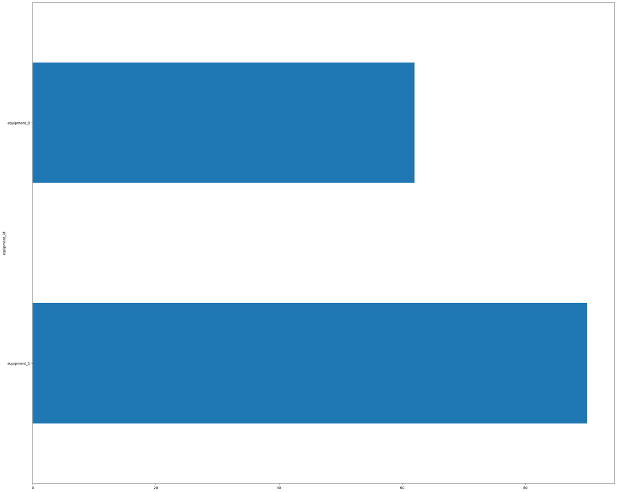

```
recipe_first recipe_first
program_12    13
program_13     7
program_38     7
program_1      7
program_35     6
program_45     5
program_8      5
program_48     5
program_11     5
program_15     5
program_20     5
program_6      5
program_9      4
program_3      4
program_24     4
program_37     4
program_31     4
program_36     3
program_44     3
program_16     3
program_0      3
program_5      3
program_46     3
program_22     3
program_4      3
program_7      3
program_19     3
program_14     2
program_28     2
program_29     2
program_30     2
program_32     2
program_21     2
program_23     2
program_2      2
program_25     1
program_41     1
program_18     1
program_26     1
program_40     1
program_52     1
program_50     1
program_49     1
program_42     1
program_33     1
program_47     1
Name: count, dtype: int64
Axes(0.125,0.11;0.775x0.77)
```

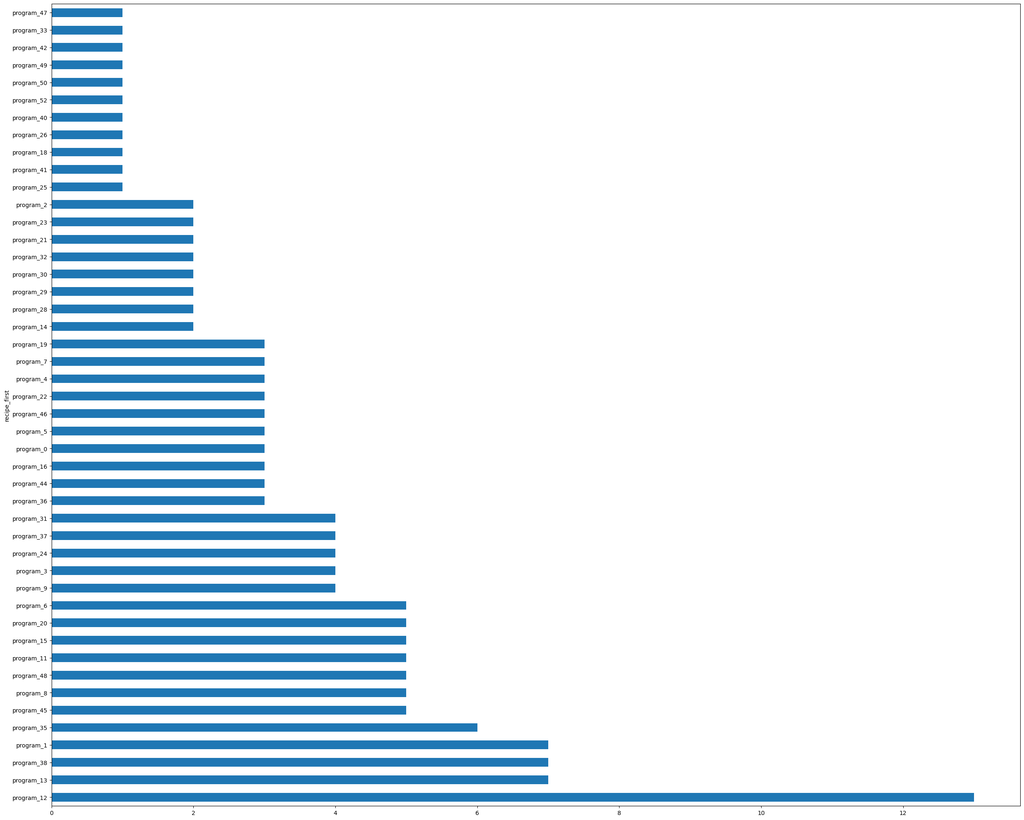

```
recipe_last recipe_last
program_12    11
program_38     8
program_11     6
program_1      6
program_8      6
program_20     5
program_15     5
program_48     5
program_31     5
program_45     5
program_0      4
program_9      4
program_4      4
program_24     4
program_28     4
program_7      4
program_37     4
program_13     4
program_35     4
program_5      4
program_22     3
program_44     3
program_46     3
program_2      3
program_21     3
program_6      3
program_19     3
program_23     3
program_3      3
program_18     2
program_16     2
program_29     2
program_30     2
program_26     2
program_36     2
program_14     1
program_32     1
program_52     1
program_47     1
program_41     1
program_33     1
program_49     1
program_10     1
program_25     1
program_40     1
program_42     1
Name: count, dtype: int64
Axes(0.125,0.11;0.775x0.77)
```

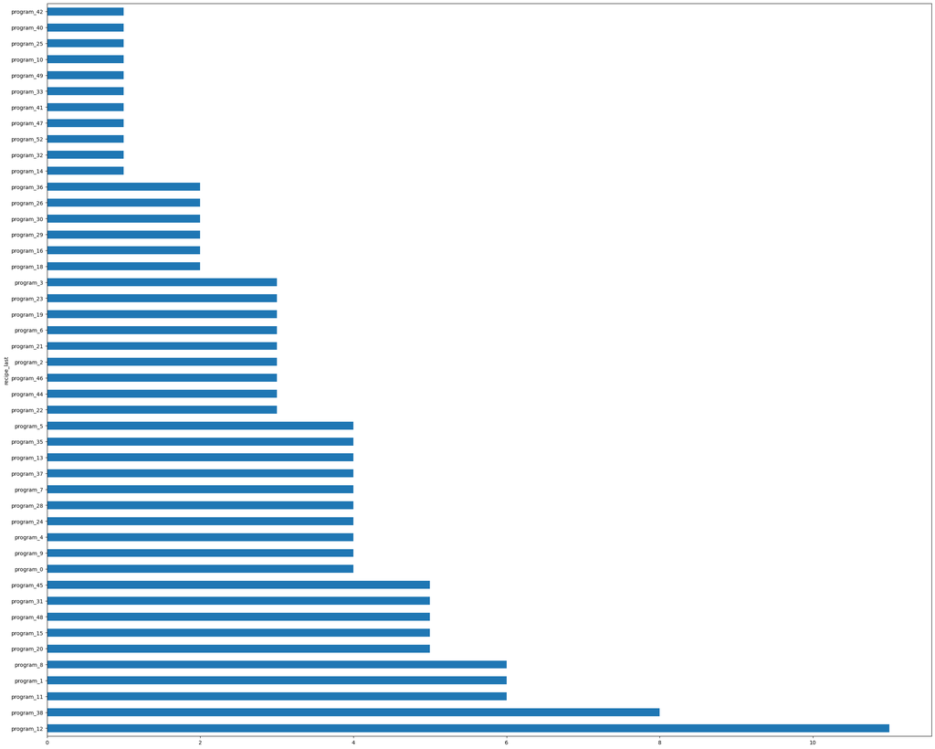

```
batch_id_last batch_id_last
batch_104    1
batch_73     1
batch_304    1
batch_150    1
batch_234    1
            ..
batch_14     1
batch_230    1
batch_158    1
batch_130    1
batch_127    1
Name: count, Length: 152, dtype: int64
Axes(0.125,0.11;0.775x0.77)
```

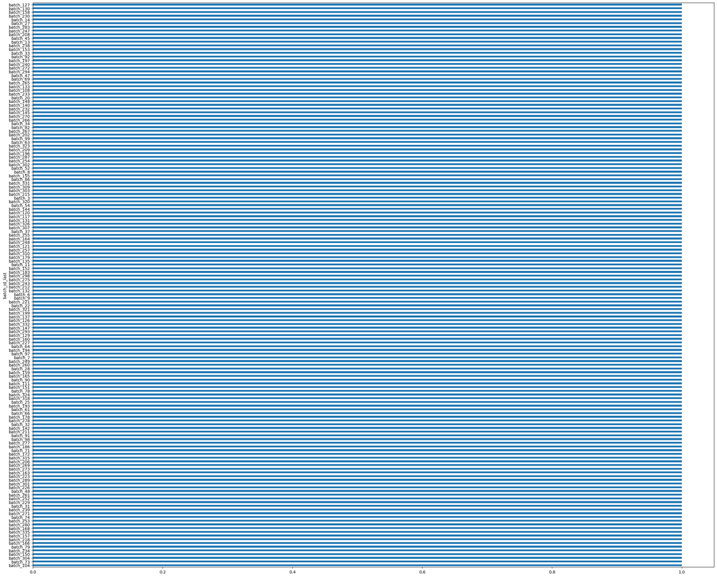

```python
# see the frequency of each values in each categorical data
for i in eda_set.select_dtypes('object'):
    print(i, eda_set[i].value_counts())
    print(eda_set[i].value_counts().plot(kind='barh',figsize=(30, 25)))
    plt.show()
```

```python
# more clearly how many unique values in each categorical feature
eda_set.select_dtypes('object').nunique()
```

```
equipment_id       2
recipe_first      46
recipe_last       46
batch_id_last    152
dtype: int64
```

```python
# I don't have full understanding of  batch_id_last column but I think id is random and i figure out each record has
#1 batch_id_last so I make assume that it does not have powers in predictions
# if I have time maybe i can try: use number in batch_id_last to see if it has any effects on ouputs.
```

### Numerical data

[output not shown]

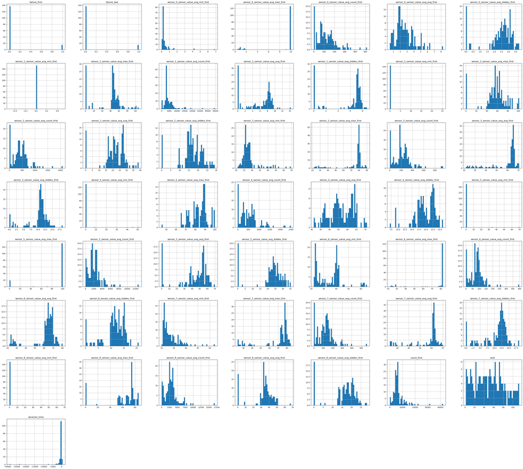

```python
# see the histogram of data
eda_set.select_dtypes('number').hist(bins=50, figsize=(50, 45))
plt.show()
```

## 1.2 Distribution of the target variable

```
failure_last
0    137
1     15
Name: count, dtype: int64
```

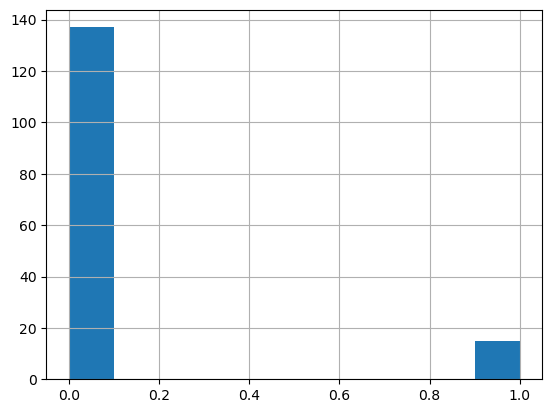

```python
eda_set.failure_last.value_counts()
eda_set.failure_last.hist()
```

```
failure_last
0    90.131579
1     9.868421
Name: count, dtype: float64
```

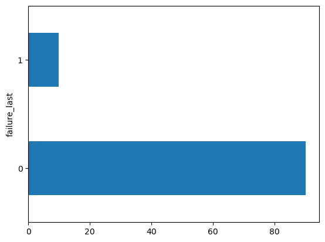

```python
# the ratio of 0 and 1
rate_0_1 = eda_set.failure_last.value_counts()/ eda_set.shape[0] *100
rate_0_1
rate_0_1.plot(kind='barh')
```

## 1.3 Create a correlation heatmap for numerical features.

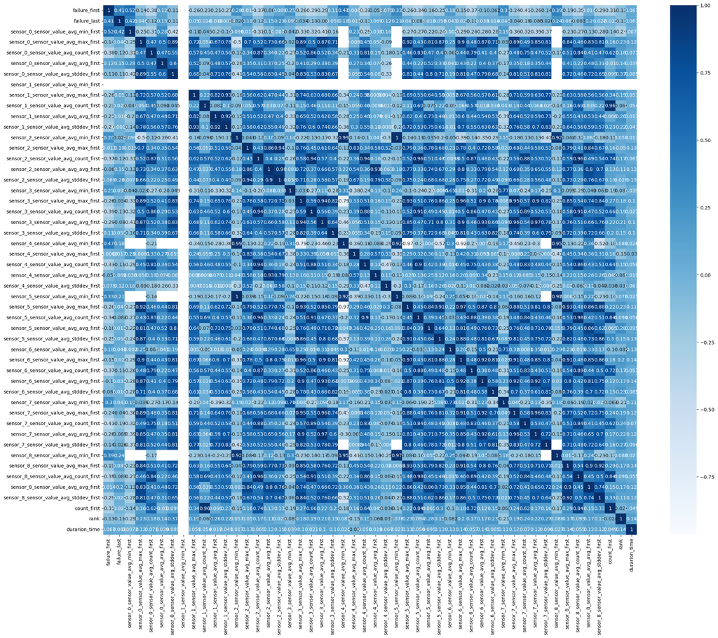

```python
# corr = eda_set.loc[:, eda_set.columns != 'b'].select_dtypes('number').corr()
# sns.heatmap(corr)

plt.figure(figsize=(25, 20))  # Set the figure size


corr = eda_set.loc[:, eda_set.columns != 'b'].select_dtypes('number').corr()
sns.heatmap(corr, cmap="Blues", annot=True)
```

```python
#To sensor_1_sensor_value_avg_min_first feature, we have all values is 0.0 -> correlation to others feature is 0
# -> it also does not have any powers in predicting
```

## 1.4 Identify the top 3 features most correlated with failure_last.

```python
corr.failure_last.sort_values(ascending=False)[1:].head(3)
```

```
sensor_0_sensor_value_avg_min_first    0.416482
failure_first                          0.408273
sensor_8_sensor_value_avg_min_first    0.243900
Name: failure_last, dtype: float64
```

# Part 2: XGBoost Model

1. Prepare the data:
   - Handle any missing values.
   - Encode categorical variables if necessary.
   - Split data into 80% training and 20% testing sets.

2.Train an XGBoost model: - Use default parameters. - Predict on the test set. 3. Evaluate the model: - Calculate and report accuracy, precision, recall, and F1-score. - Plot the ROC curve and report the AUC score. 4. Feature Importance: - Plot the top 5 most important features. - Briefly explain their significance for predicting equipment failure.

## 2.1 Prepare the data

```python
# after EDA, we figure out which columns should be removed from training,
# we did a few feature engineering on above, so:

train_set_filter = train_set.drop(['batch_id_last','sensor_1_sensor_value_avg_min_first','start_time_last','end_time_first','failure_last'],axis=1)
y_train = train_set.failure_last
train_set_filter,y_train
```

```
(    equipment_id recipe_first recipe_last  failure_first  \
 51   equipment_0   program_21  program_21              1
 35   equipment_0   program_12  program_19              0
 118  equipment_1   program_13  program_45              0
 60   equipment_0   program_35   program_0              0
 161  equipment_1   program_16  program_24              0
 ..           ...          ...         ...            ...
 106  equipment_1   program_20  program_31              0
 14   equipment_0    program_4  program_21              0
 92   equipment_1   program_47  program_45              0
 179  equipment_1   program_48   program_2              0
 102  equipment_1   program_36  program_37              0

      sensor_0_sensor_value_avg_min_first  sensor_0_sensor_value_avg_max_first  \
 51                              0.464987                            10.000000
```

[output cut: 479 more lines]

## 2.2 Training pipeline

```python
# pipeline for training
# cause it is imbalanced data, so we calculate scale_pos_weight between negative and positive class
# to help have parameter allows the model to compensate for this by assigning more weight to the minority class,
# making the model more sensitive to misclassifications of the minority class.


neg_class = (y_train == 0).sum()
pos_class = (y_train == 1).sum()

scale_pos_weight = neg_class / pos_class

# filter numerical and categorical columns
numerical_columns_selector = selector(dtype_exclude=object)
numerical_columns = numerical_columns_selector(train_set_filter)


categorical_columns_selector = selector(dtype_include=object)
categorical_columns = categorical_columns_selector(train_set_filter)

# transform for each type
numeric_transformer = Pipeline(steps=[
    ('imputer', SimpleImputer(strategy='mean')),   # Fill missing numerical values with the mean
    ('scaler', StandardScaler())                  # Normalize numerical data
])

categorical_transformer = Pipeline(steps=[
    ('imputer', SimpleImputer(strategy='most_frequent')),  # Fill missing categorical values with the most frequent value
    ('encoder', OneHotEncoder(handle_unknown='ignore'))    # One-hot encode the categorical features
])

# Combine the transformations for numeric and categorical data
preprocessor = ColumnTransformer(transformers=[
    ('num', numeric_transformer, numerical_columns),
    ('cat', categorical_transformer, categorical_columns)
])

xgb = XGBClassifier(use_label_encoder=False, eval_metric='logloss')


# Create the full pipeline with preprocessor and classifier
pipeline = Pipeline(steps=[
    ('preprocessor', preprocessor),
    ('classifier', XGBClassifier(use_label_encoder=False, eval_metric='logloss',scale_pos_weight=scale_pos_weight))
])

# Train the model
pipeline.fit(train_set_filter, y_train)

# Predict on the test data
# y_pred = pipeline.predict(X_test)

# # Evaluate the model
# accuracy = accuracy_score(y_test, y_pred)
# print(f'Accuracy: {accuracy:.2f}')
```

```
Pipeline(steps=[('preprocessor',
                 ColumnTransformer(transformers=[('num',
                                                  Pipeline(steps=[('imputer',
                                                                   SimpleImputer()),
                                                                  ('scaler',
                                                                   StandardScaler())]),
                                                  ['failure_first',
                                                   'sensor_0_sensor_value_avg_min_first',
                                                   'sensor_0_sensor_value_avg_max_first',
                                                   'sensor_0_sensor_value_avg_count_first',
                                                   'sensor_0_sensor_value_avg_avg_first',
                                                   'sensor_0_sensor_value_avg_stddev_...
                               feature_types=None, gamma=None, grow_policy=None,
                               importance_type=None,
                               interaction_constraints=None, learning_rate=None,
                               max_bin=None, max_cat_threshold=None,
                               max_cat_to_onehot=None, max_delta_step=None,
                               max_depth=None, max_leaves=None,
                               min_child_weight=None, missing=nan,
                               monotone_constraints=None, multi_strategy=None,
                               n_estimators=None, n_jobs=None,
                               num_parallel_tree=None, random_state=None, ...))])
```

```python
# Evaluate the model on training set
y_train_pred = pipeline.predict(train_set_filter)
accuracy_train = accuracy_score(y_train, y_train_pred)
accuracy_train
```

```
1.0
```

The indication of overfitting cause accuracy is 1 in training set -> need to see more on test set.

## 2.3 Evaluating on testing set:

```python
# transform test data

test_set[['start_time_last','end_time_first']] = test_set[['start_time_last','end_time_first']].apply(pd.to_datetime)
test_set['durarion_time'] = test_set.end_time_first - test_set.start_time_last
test_set['durarion_time']= test_set.durarion_time.dt.total_seconds() / 60
test_set_filter = test_set.drop(['batch_id_last','sensor_1_sensor_value_avg_min_first',
                                 'start_time_last','end_time_first','failure_last'],axis=1)

y_test= test_set.failure_last

y_pred = pipeline.predict(test_set_filter)

# Evaluate the model
# Calculate and report accuracy, precision, recall, and F1-score.

precision = precision_score(y_test, y_pred)
recall = recall_score(y_test, y_pred)
f1 = f1_score(y_test, y_pred)

accuracy = accuracy_score(y_test, y_pred)
print(f'Accuracy: {accuracy:.5f}')

print(precision,recall,f1)
```

```
Accuracy: 0.78947
0.0 0.0 0.0
```

```python
## see y_test and y_pred
y_test
y_pred
```

```
175    0
180    0
111    0
65     0
101    0
15     0
9      1
16     0
141    0
124    0
109    0
95     0
18     0
164    0
85     0
```

[output cut: 24 more lines]

```
array([0, 0, 0, 0, 0, 1, 0, 0, 0, 0, 0, 0, 0, 1, 1, 0, 0, 0, 0, 0, 0, 0,
       0, 0, 0, 0, 0, 1, 0, 0, 0, 0, 0, 0, 0, 0, 0, 0])
```

```
AUC Score: 0.4411764705882353
```

```
(0.0, 1.0)
```

```
(0.0, 1.05)
```

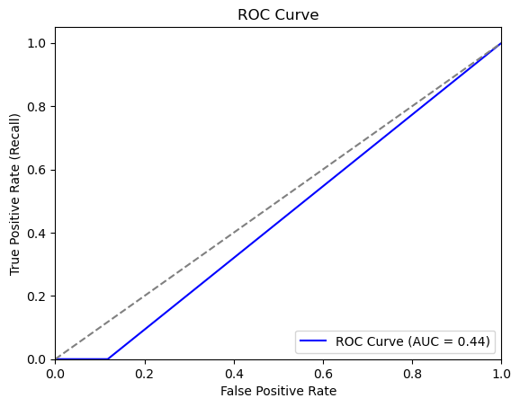

```python
## Plot the ROC curve and report the AUC score.

fpr, tpr, thresholds = roc_curve(y_test, y_pred)

#  Calculate the AUC Score
auc_score = roc_auc_score(y_test, y_pred)
print(f'AUC Score: {auc_score}')

#  Plot the ROC Curve
plt.figure()
plt.plot(fpr, tpr, color='blue', label=f'ROC Curve (AUC = {auc_score:.2f})')
plt.plot([0, 1], [0, 1], color='gray', linestyle='--')  # Diagonal line (random classifier)
plt.xlim([0.0, 1.0])
plt.ylim([0.0, 1.05])
plt.xlabel('False Positive Rate')
plt.ylabel('True Positive Rate (Recall)')
plt.title('ROC Curve')
plt.legend(loc="lower right")
plt.show()
```

AUC is too low, even < 0.5, this is cause we have few data (only 152 data for training, and it is imbalanced, so only 9% of data is label_1. )

## Feature importance

```python
#  Access the XGBoost model from the pipeline
xgb_model = pipeline.named_steps['classifier']

#  Get feature importances
feature_importances = xgb_model.feature_importances_

# Get feature names AFTER preprocessing
# Use the pipeline's preprocessing step to transform the training data
preprocessor = pipeline.named_steps['preprocessor']
X_train_transformed = preprocessor.transform(train_set_filter)

# get the transformed feature names, which may differ from the raw ones
if isinstance(train_set_filter, pd.DataFrame):
    feature_names = preprocessor.get_feature_names_out(train_set_filter.columns)
else:
    feature_names = [f'Feature {i}' for i in range(X_train_transformed.shape[1])]

#  Create a DataFrame for better visualization

# Ensure feature_importances and feature_names have the same length
assert len(feature_importances) == len(feature_names), "Feature importance and feature names length mismatch"

importance_df = pd.DataFrame({
    'Feature': feature_names,
    'Importance': feature_importances
})

# Sort features by importance
importance_df = importance_df.sort_values(by='Importance', ascending=False)

# Display the importance
print(importance_df)
importance_df.sort_values(by= 'Importance',ascending=False)
```

```
                                         Feature  Importance
1       num__sensor_0_sensor_value_avg_min_first    0.179643
96                    cat__recipe_last_program_1    0.094292
23      num__sensor_4_sensor_value_avg_avg_first    0.088172
52                  cat__recipe_first_program_12    0.080872
9    num__sensor_1_sensor_value_avg_stddev_first    0.055879
..                                           ...         ...
67                  cat__recipe_first_program_28    0.000000
66                  cat__recipe_first_program_26    0.000000
65                  cat__recipe_first_program_25    0.000000
64                  cat__recipe_first_program_24    0.000000
140                   cat__recipe_last_program_9    0.000000

[141 rows x 2 columns]
```

|  | Feature | Importance |
| --- | --- | --- |
| 1 | num__sensor_0_sensor_value_avg_min_first | 0.179643 |
| 96 | cat__recipe_last_program_1 | 0.094292 |
| 23 | num__sensor_4_sensor_value_avg_avg_first | 0.088172 |
| 52 | cat__recipe_first_program_12 | 0.080872 |
| 9 | num__sensor_1_sensor_value_avg_stddev_first | 0.055879 |
| ... | ... | ... |
| 130 | cat__recipe_last_program_45 | 0.000000 |
| 131 | cat__recipe_last_program_46 | 0.000000 |
| 115 | cat__recipe_last_program_29 | 0.000000 |
| 114 | cat__recipe_last_program_28 | 0.000000 |
| 140 | cat__recipe_last_program_9 | 0.000000 |

141 rows × 2 columns

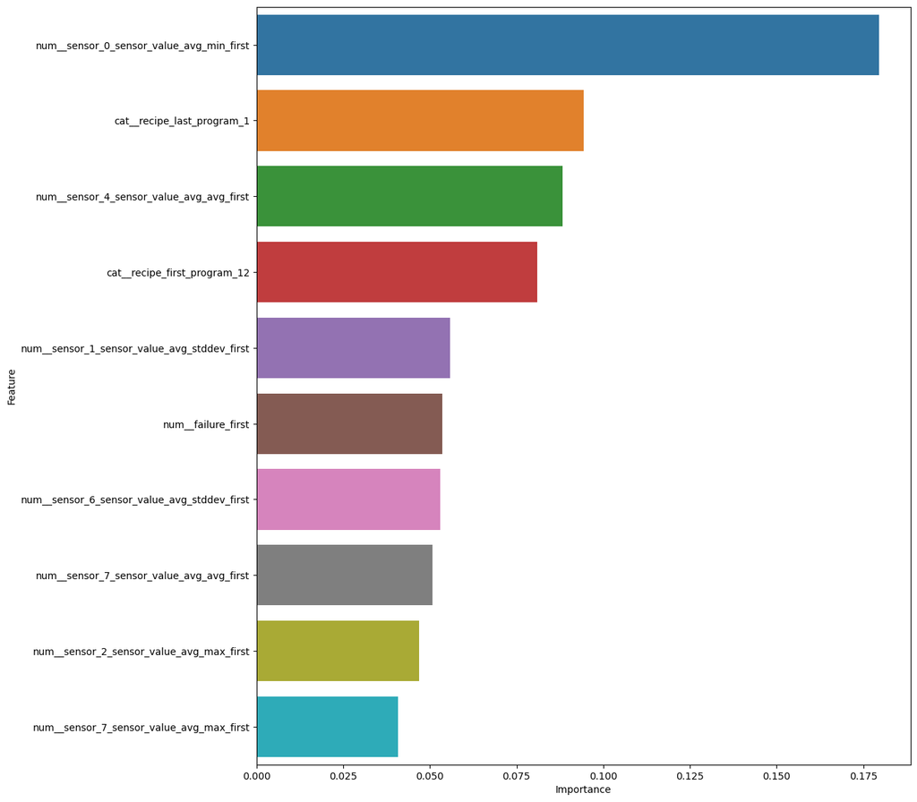

```python
# I show 10 features with the highest feature importance score , 5 is the the top 5 in the figure following

fig, axes = plt.subplots(1, 1, figsize= (12, 14))

sns.barplot(data=importance_df.sort_values(by= 'Importance',ascending=False).head(10),
            y = 'Feature', x = 'Importance', ax = axes)
```

Top 5 most important features is 5 features that have the largest contribution to the predictive power of the model. they are 5 features most influential in predicting the target variable.

## Hyperparameter tuning

```python
pipeline = Pipeline(steps=[
    ('preprocessor', preprocessor),
    ('classifier', XGBClassifier(use_label_encoder=False, eval_metric='logloss',scale_pos_weight=scale_pos_weight))
])

# hyperparam to tune

param_grid = {
    'classifier__n_estimators': [100, 200, 500],
    'classifier__max_depth': [3, 5, 7, 10],
    'classifier__learning_rate': [0.01, 0.1, 0.2],
    'classifier__subsample': [0.6, 0.8, 1.0],
    'classifier__colsample_bytree': [0.6, 0.8, 1.0],
    'classifier__gamma': [0, 0.1, 0.3, 0.5],
    'classifier__min_child_weight': [1, 3, 5],
    'classifier__scale_pos_weight': [1, 5, scale_pos_weight, scale_pos_weight+5]  # Adjust based on class imbalance
}

#  Define RandomizedSearchCV
random_search = RandomizedSearchCV(
    estimator=pipeline,
    param_distributions=param_grid,
    n_iter=50,  # Number of hyperparameter combinations to try
    scoring='f1',  # Metric to optimize (e.g., f1, accuracy, etc.)
    cv=3,  # 3-fold cross-validation
    verbose=2,
    random_state=42,
    n_jobs=-1  # Use all available cores
)

#  Fit RandomizedSearchCV on training data
random_search.fit(train_set_filter, y_train)

#  Print the best hyperparameters
print("Best Hyperparameters:", random_search.best_params_)

# Predict using the best estimator
y_pred = random_search.best_estimator_.predict(test_set_filter)

#  Evaluate the model
print(classification_report(y_test, y_pred))
```

```
Fitting 3 folds for each of 50 candidates, totalling 150 fits
```

```
RandomizedSearchCV(cv=3,
                   estimator=Pipeline(steps=[('preprocessor',
                                              ColumnTransformer(transformers=[('num',
                                                                               Pipeline(steps=[('imputer',
                                                                                                SimpleImputer()),
                                                                                               ('scaler',
                                                                                                StandardScaler())]),
                                                                               ['failure_first',
                                                                                'sensor_0_sensor_value_avg_min_first',
                                                                                'sensor_0_sensor_value_avg_max_first',
                                                                                'sensor_0_sensor_value_avg_count_first',
                                                                                'sensor_0_sensor_value_avg_avg_first',...
                                                                         1.0],
                                        'classifier__gamma': [0, 0.1, 0.3, 0.5],
                                        'classifier__learning_rate': [0.01, 0.1,
                                                                      0.2],
                                        'classifier__max_depth': [3, 5, 7, 10],
                                        'classifier__min_child_weight': [1, 3,
                                                                         5],
                                        'classifier__n_estimators': [100, 200,
                                                                     500],
                                        'classifier__scale_pos_weight': [1, 5,
                                                                         9.133333333333333,
                                                                         14.133333333333333],
                                        'classifier__subsample': [0.6, 0.8,
                                                                  1.0]},
                   random_state=42, scoring='f1', verbose=2)
```

```
Best Hyperparameters: {'classifier__subsample': 0.6, 'classifier__scale_pos_weight': 5, 'classifier__n_estimators': 500, 'classifier__min_child_weight': 3, 'classifier__max_depth': 5, 'classifier__learning_rate': 0.1, 'classifier__gamma': 0.1, 'classifier__colsample_bytree': 0.6}
              precision    recall  f1-score   support

           0       0.89      0.91      0.90        34
           1       0.00      0.00      0.00         4

    accuracy                           0.82        38
   macro avg       0.44      0.46      0.45        38
weighted avg       0.79      0.82      0.80        38
```

Precision, recall, f1 for label_1 still 0 -> so sorry, but we have too few data.

```
AUC Score: 0.45588235294117646
```

```
(0.0, 1.0)
```

```
(0.0, 1.05)
```

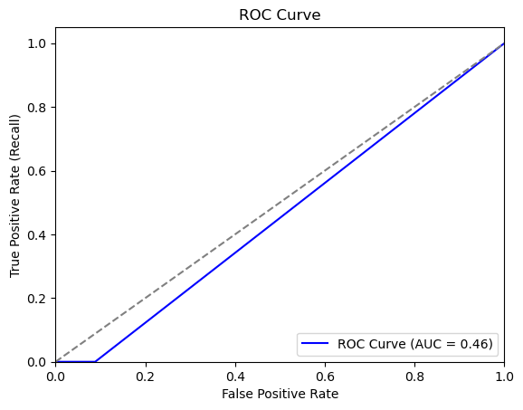

[output not shown]

[output cut: 115 more lines]

```python
fpr, tpr, thresholds = roc_curve(y_test, y_pred)

#  Calculate the AUC Score
auc_score = roc_auc_score(y_test, y_pred)
print(f'AUC Score: {auc_score}')

#  Plot the ROC Curve
plt.figure()
plt.plot(fpr, tpr, color='blue', label=f'ROC Curve (AUC = {auc_score:.2f})')
plt.plot([0, 1], [0, 1], color='gray', linestyle='--')  # Diagonal line (random classifier)
plt.xlim([0.0, 1.0])
plt.ylim([0.0, 1.05])
plt.xlabel('False Positive Rate')
plt.ylabel('True Positive Rate (Recall)')
plt.title('ROC Curve')
plt.legend(loc="lower right")
plt.show()
```